# Institute of Integrative Biology PhD Biological Sciences

Bryony Allen [^1]

Andy Fenton (supervisor) [^2]

2019-04-01

# 1 Abstract

**Key-words:** *Batrachochytrium dendrobatidis*, chytridmycosis, ranavirus, coinfection, multi-host, within-host interactions, between-host interactions, host-pathogen interaction, amphibian

# 2 Introduction

The notable, global decline of amphibians has largely been attributed to parasitism; the two pathogens of greatest conservation concern being Ranavirus and *Batrachochytrium dendrobatidis* (Bd). While both pathogens have been studied extensively the majority of these studies have taken a one-host, one-pathogen approach. In nature, things are rarely that simple; pathogens often infect multiple host species and hosts can be parasitised by multiple pathogen species. Increasingly, we are seeing field studies reporting co-infection occurring in multiple host species. Yet our understanding of these complex host-pathogen interactions and the implications on disease transmission and persistence maintenance within a host community remains limited.  
To help unpick the tangled dynamics of this multi-host, multi-pathogen system we empirically tested how susceptibility, infectiousness and burden of disease changed with infection scenario (single vs coinfection) across a panel of host species (*Bufo bufo*, *Rana temporaria* and *Alytes muletensis*) that range in their reported susceptibility. We demonstrate that disease prevalence and infection burden is context dependent. Pathogen prevalence appears to be particularly linked to the exposure scenario whereas host species determined endpoint pathogen burden, in particular, *Bufo bufo* exhibited higher Bd load regardless of exposure regimes. *While Bd was detected in all host species across treatment groups, the exposure sequence determined the extent of ranaviral infection with, significantly higher disease prevalence in co-infection scenarios.* Understanding the susceptibility and infectiousness of each host at an individual level allows us to predict how host species community composition influences the establishment and persistence of both pathogens, singularly and as coinfections, at the community level. Our study provides previously lacking empirical evidence of within-host dynamics influencing disease outcome under different exposure scenarios (single vs co-infection).

## 2.1 Within-host Dynamics (Co-infection)

## 2.2 Between-host Dynamics (Shedding)

# 3 Aims:

1. Establish the contributions of hosts to the environmental “pool” of infectious particles, across species at an individual level, to understand variations in host infectiousness and by proxy transmission.
   1. Understand how host infectiousness, measured by quantifying Bd zoospore and ranavirus virons shed into the water body, changes with the exposure regime in single pathogen vs. co-infection scenarios.
   2. Assess the viability of infectious particles shed into the aquatic environment.
2. Ascertain whether the sequence of exposure to co-infecting pathogens (Bd and Rv) alters the disease outcome for the host and subsequent transmission of the pathogens.
3. Build an understanding of the spatial dynamics of Bd zoospores in the aquatic environment, focussing on zoospore activity and trajectory.
4. Elucidate the role of specific behaviours in modifying contact rates and how that influences transmission rates, within and between species.
   1. Establish whether exposure to pathogens (Bd and/or Rv) changes tadpole behaviour (e.g. activity rates, foraging performance, and aggregation behaviour).
   2. Identify which species-to-species and individual-to-individual contacts alter pathogen transmission.
   3. Assess how transmission rates change under different scenarios that encourage shifts in contact rates (e.g. variations in host density, temperature and food availability). V. Parametrizing the transmission coefficients of Bd in a multi-host system to develop realistic models.
5. Combine these results into a predictive framework to understand how individual-level behaviours influence disease transmission in natural ecological communities.

# 4 Methods

## 4.1 Study Species

In order to capture a range of host susceptibilities to infection by Bd and/or Rv I examined shedding rates and infection intensity of two co-occurring species (B. bufo & R. temporaria) that display contrasting resistances, and one other species (A. muletensis) documented to respond distinctly to Bd exposure but which has no empirical records of ranavirus exposure.

## 4.4 Within-host Dynamics (Co-infection)

** DNA extractions and quantification ** The Bd infection load of tadpoles was confirmed by excision and DNA extraction of mouthparts using Prepman Ultra (Life Technologies) as per Hyatt et al. (2007). Extracts were screened by the qPCR diagnostic outlined in (Boyle et al., 2004) which targets the ITS-1 and 5.8S regions and diluted 1:10 before qPCR to avoid inhibition. The infection load with be express in genomic equivalents (GE), where one GE is equivalent to a single zoospore. The quantification of ranaviral DNA from tissue samples (mainly livers and kidneys) of the tadpoles stored in 100% ethanol was by DNeasy Blood and Tissue (Qiagen) extraction following the manufacturers protocol. DNA samples were then analysed with a qPCR assay specific to the ranaviral major capsid protein (MCP) sequence and normalised by host cell quantity as outlined in Leung et al. (2017).

## 4.5 Between-host Dynamics (Shedding)

**Filtration** Water samples were obtained every day for the first four days and then day 9 post- exposure, to capture the Bd reproduction cycle (DiRenzo, Langhammer, Zamudio, & Lips, 2014b; Garmyn et al., 2012) and Rv attenuation (Duffus et al., 2014). We modified the soak technique used by Di Renzo et al. (2014) and Reeder et al. (2012), increasing the soak period to 4 hours in 50ml of aged tap water to balance the need to sensitively detect zoospores/virions shed with the considerations of the tadpoles welfare needs. The soak water was filtered through a cellulose nitrate filter membrane (Nalgene Analytical Test Filter Funnel, ThermoFisher), 0.45um pore size to capture 1-2m to 3-5m zoospores (Berger, Speare, & Kent, 1999; Longcore et al., 1999), by a vacuum manifold. Following filtration, each membrane was removed from the filter unit, cut in half using a sterile scalpel blade, and stored at -20oC for a week before being transferred to -80oC until processing. After the last shedding period and water filtration (dpi 9) tadpoles were euthanised, under licence, by buffered (pH 7.0) 5 mg/L tricaine methylsulfonate (MS- 222) and then stored in 100% ethanol.

**Viability (EMA)**  
Quantification of viable zoospores shed into the housing container over the course of the shedding period (4 days) was achieved by ethidium monoazide (EMA) treatment following the protocol in (Blooi, Martel, Vercammen, & Pasmans, 2013). In brief, at 4 days post-infection, two sub-samples were taken from the housing container, one to be treated with EMA and the other untreated before DNA extraction by Prepman Ultra (as described below). EMA binds to dead zoospores penetrating their compromised membranes and blocks PCR amplification thus EMA treated samples represent the viable proportion of Bd zoospores in a sample compared to an untreated sample that records both the viable and dead fractions.

** DNA extractions and quantification** a DNA extraction was performed for each filter membrane half. One half underwent extraction by Prepman Ultra (Life Technologies) following the procedure described in Hyatt et al. (2007) to target bd. Whereas DNeasy Blood & Tissue kit was used to isolate Rv DNA following the protocol Goldberg et al.(2011) with the modifications outlined by (Kosch & Summers (2013). All DNA extractions will be assayed by quantitative polymerase chain reaction (qPCR) specific to each pathogen and run in duplicate. A positive result was scored if both wells amplify above the detection threshold when compared to the curve of standards.

**Shedding Model**

## 4.6 Equations

$$\frac{1}{\sqrt{2\pi}\sigma}e^{-(x-\mu_i)^2/(2\sigma^2)}$$

# 5 Results

## 5.1 Within-host Dynamics (Co-infection)

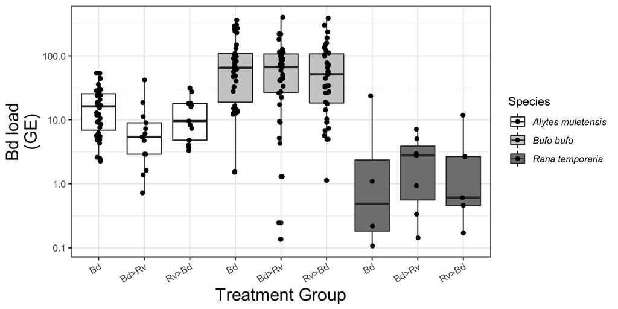

## 5.2 Between-host Dynamics

### 5.2.1 Shedding

[output not shown]

### 5.2.2 Viability

# 6 Discussion

**Ethics** All work was carried out under British Home Office licencing following ethical approval by the Zoological Society of London’s Ethics Committee.  
Personal Licence (PIL): Bryony Allen I41AEB105 Project Licence (PPL): Trenton Garner P8897246A

**Biosecurity** In line with ZSL guidelines all equipment and infectious material (water and animals) was decontaminated by exposure to 1% Virkon (Johnson et al., 2003) or by autoclaving and incineration.

**Authors contributions**

**Acknowledgments** I would like to thank the animal husbandry team at ZSL…

# 7 References

# 8 Progress and Development

## 8.1 Knowledge & Intellectual Abilities

- Nov 2018 ZSL Symposium: Linking behaviour to populations and communities: how can behavioural ecology inform conservation?
- Mar 2019 Nature Masterclass - workshop
- Apr 2019 ZSL Symposium: Mitigating single pathogen and co-infections that threaten amphibian biodiversity

## 8.2 Personal Effectiveness

- Apr 2019 ACCE training: Data and Project Management
- Apr 2019 IIB training: Meet the Viva Panel

## 8.3 Research Governance & Organisation

- Mar 2019 Nature Masterclass - workshop
- +++++++++ Apr 2019 Ethical Review by ZSL Ethics Committee ++++++++++

## 8.4 Engagement Influence & Impact

# 9 Thesis Plan

**Chapter 1:** Literature Review: *introducing amphibian decline and the associated diseases (Bd and Rv), how disease dynamics are modelled, and behavioural responses to disease.*

**Chapter 2:** Within-host dynamic: *co-infection*

**Chapter 3:** Between-host dynamics: *transmission and shedding models*

**Chapter 4:** Modelling transmission across scales: *multi-species*

**Chapter 5:** Behaviour & Transmission

# 10 Supplementary Material

## 10.1

[^1]: University of Liverpool & Zoological Society of London
[^2]: University of Liverpool